# Lab5_SNC

## Exercise 3

Add a title and more informative x and y axes labels to the plot in Exercise 2

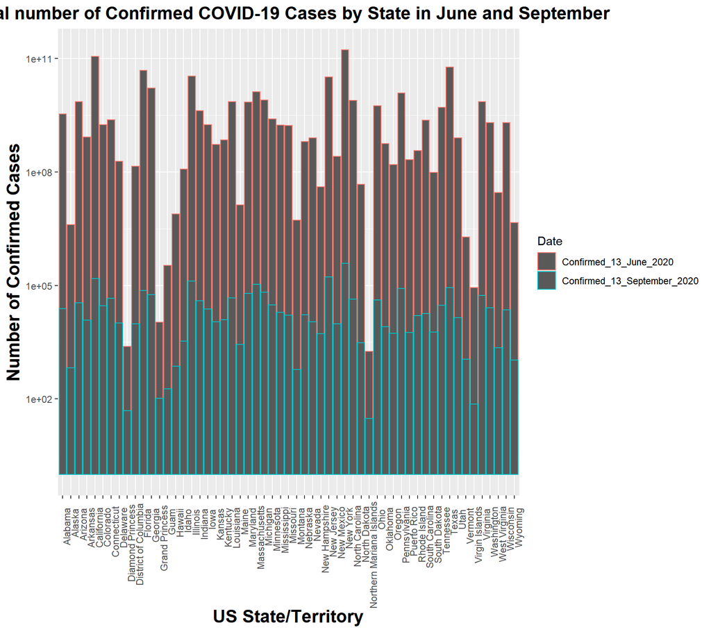

```r
advanced_confirmed_states_plot <- basic_confirmed_states_plot +
  labs(x = "US State/Territory", y = "Number of Confirmed Cases", title = "Total number of Confirmed COVID-19 Cases by State in June and September") +
  theme(axis.title = element_text(size = 16, face = 'bold'),
        plot.title = element_text (size = 16, face = 'bold', hjust = 0.5))
advanced_confirmed_states_plot
```

## Exercise 4

Using the time series data, plot the total number of worldwide confirmed deaths per day over time

```r
# Use the time series data for deaths from earlier in the tutorial -
head(time_series_deaths) # Checking what it looks like
```

```
## # A tibble: 6 x 252
##   Province_State Country_Region   Lat   Long `1/22/20` `1/23/20` `1/24/20`
##   <chr>          <chr>          <dbl>  <dbl>     <dbl>     <dbl>     <dbl>
## 1 <NA>           Afghanistan     33.9  67.7          0         0         0
## 2 <NA>           Albania         41.2  20.2          0         0         0
## 3 <NA>           Algeria         28.0   1.66         0         0         0
## 4 <NA>           Andorra         42.5   1.52         0         0         0
## 5 <NA>           Angola         -11.2  17.9          0         0         0
## 6 <NA>           Antigua and B~  17.1 -61.8          0         0         0
## # ... with 245 more variables: `1/25/20` <dbl>, `1/26/20` <dbl>,
## #   `1/27/20` <dbl>, `1/28/20` <dbl>, `1/29/20` <dbl>, `1/30/20` <dbl>,
## #   `1/31/20` <dbl>, `2/1/20` <dbl>, `2/2/20` <dbl>, `2/3/20` <dbl>,
## #   `2/4/20` <dbl>, `2/5/20` <dbl>, `2/6/20` <dbl>, `2/7/20` <dbl>,
## #   `2/8/20` <dbl>, `2/9/20` <dbl>, `2/10/20` <dbl>, `2/11/20` <dbl>,
## #   `2/12/20` <dbl>, `2/13/20` <dbl>, `2/14/20` <dbl>, `2/15/20` <dbl>,
## #   `2/16/20` <dbl>, `2/17/20` <dbl>, `2/18/20` <dbl>, `2/19/20` <dbl>,
## #   `2/20/20` <dbl>, `2/21/20` <dbl>, `2/22/20` <dbl>, `2/23/20` <dbl>,
## #   `2/24/20` <dbl>, `2/25/20` <dbl>, `2/26/20` <dbl>, `2/27/20` <dbl>,
## #   `2/28/20` <dbl>, `2/29/20` <dbl>, `3/1/20` <dbl>, `3/2/20` <dbl>,
## #   `3/3/20` <dbl>, `3/4/20` <dbl>, `3/5/20` <dbl>, `3/6/20` <dbl>,
## #   `3/7/20` <dbl>, `3/8/20` <dbl>, `3/9/20` <dbl>, `3/10/20` <dbl>,
## #   `3/11/20` <dbl>, `3/12/20` <dbl>, `3/13/20` <dbl>, `3/14/20` <dbl>,
## #   `3/15/20` <dbl>, `3/16/20` <dbl>, `3/17/20` <dbl>, `3/18/20` <dbl>,
## #   `3/19/20` <dbl>, `3/20/20` <dbl>, `3/21/20` <dbl>, `3/22/20` <dbl>,
## #   `3/23/20` <dbl>, `3/24/20` <dbl>, `3/25/20` <dbl>, `3/26/20` <dbl>,
## #   `3/27/20` <dbl>, `3/28/20` <dbl>, `3/29/20` <dbl>, `3/30/20` <dbl>,
## #   `3/31/20` <dbl>, `4/1/20` <dbl>, `4/2/20` <dbl>, `4/3/20` <dbl>,
## #   `4/4/20` <dbl>, `4/5/20` <dbl>, `4/6/20` <dbl>, `4/7/20` <dbl>,
## #   `4/8/20` <dbl>, `4/9/20` <dbl>, `4/10/20` <dbl>, `4/11/20` <dbl>,
## #   `4/12/20` <dbl>, `4/13/20` <dbl>, `4/14/20` <dbl>, `4/15/20` <dbl>,
## #   `4/16/20` <dbl>, `4/17/20` <dbl>, `4/18/20` <dbl>, `4/19/20` <dbl>,
## #   `4/20/20` <dbl>, `4/21/20` <dbl>, `4/22/20` <dbl>, `4/23/20` <dbl>,
## #   `4/24/20` <dbl>, `4/25/20` <dbl>, `4/26/20` <dbl>, `4/27/20` <dbl>,
## #   `4/28/20` <dbl>, `4/29/20` <dbl>, `4/30/20` <dbl>, `5/1/20` <dbl>,
## #   `5/2/20` <dbl>, `5/3/20` <dbl>, ...
```

```r
# Pivoting to long format by dates, then summarizing for worldwide statistics by date
time_series_deaths_worldwide <- time_series_deaths %>%
  select(-c(Lat, Long)) %>% # Filter out the columns Lat and Long
  pivot_longer(-c(Country_Region, Province_State), names_to = "Date", values_to = "Deaths") %>% # Must preserve Province_state, too
  group_by(Date) %>%
  summarize(Total_Deaths = sum(Deaths))
head(time_series_deaths_worldwide) # Check that it was created properly
```

```
## # A tibble: 6 x 2
##   Date    Total_Deaths
##   <chr>          <dbl>
## 1 1/22/20           17
## 2 1/23/20           18
## 3 1/24/20           26
## 4 1/25/20           42
## 5 1/26/20           56
## 6 1/27/20           82
```

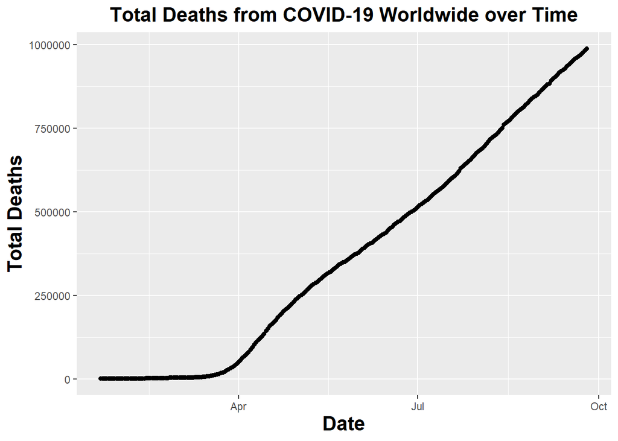

```r
# Now adjust the date format and plot -
time_series_deaths_worldwide$Date <- mdy(time_series_deaths_worldwide$Date)
plot_time_series_deaths_worldwide <- ggplot(time_series_deaths_worldwide, aes(x = Date, y = Total_Deaths)) +
  geom_point() +
  geom_line() +
  labs(y = "Total Deaths", title = "Total Deaths from COVID-19 Worldwide over Time") +
  theme(axis.title = element_text(size = 16, face = 'bold'),
        plot.title = element_text (size = 16, face = 'bold', hjust = 0.5))
plot_time_series_deaths_worldwide
```

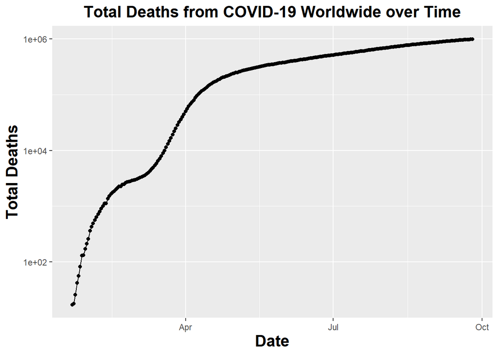

```r
# For fun, here it is with log10 axes -
plot_time_series_deaths_worldwide + scale_y_log10()
```

## Exercise 5

Use mutate() to add a new column of deaths/confirmed cases to the time series data

```r
# Start with the combined time_series_long_joined tibble from earlier that has the
# Confirmed and Deaths for each observations for each date, then mutate to add another column
time_series_long_joined_ratio <- time_series_long_joined %>%
  mutate(Death_Confirmed_Ratio = Deaths/Confirmed)
  # Decided to keep the NaN (not a number) values as is since data aren't plotted yet
head(time_series_long_joined_ratio) # New column is now added
```

```
## # A tibble: 6 x 8
##   Province_State Country_Region   Lat  Long Date       Confirmed Deaths
##   <chr>          <chr>          <dbl> <dbl> <date>         <dbl>  <dbl>
## 1 <NA>           Afghanistan     33.9  67.7 2020-01-22         0      0
## 2 <NA>           Afghanistan     33.9  67.7 2020-01-23         0      0
## 3 <NA>           Afghanistan     33.9  67.7 2020-01-24         0      0
## 4 <NA>           Afghanistan     33.9  67.7 2020-01-25         0      0
## 5 <NA>           Afghanistan     33.9  67.7 2020-01-26         0      0
## 6 <NA>           Afghanistan     33.9  67.7 2020-01-27         0      0
## # ... with 1 more variable: Death_Confirmed_Ratio <dbl>
```

## Exercise 6

Plot the US deaths/confirmed cases over time

```r
# Take the above data set and filter out non-US data, then summarize for total US deaths
# and confirmed, then re-calculated ratio for entire US, pivot_longer to get just the ratio,
# and plot over time. Note that this method will yield slightly different results than
# averaging all the Death_Confirmed_Ratio values due to the nature of the ratio
time_series_US_ratio <- time_series_long_joined_ratio %>%
  filter(Country_Region == "US") %>%
  group_by(Date) %>%
  summarize(Total_Deaths = sum(Deaths), Total_Confirmed = sum(Confirmed)) %>%
  mutate(Death_Confirmed_Ratio = Total_Deaths/Total_Confirmed)
head(time_series_US_ratio)
```

```
## # A tibble: 6 x 4
##   Date       Total_Deaths Total_Confirmed Death_Confirmed_Ratio
##   <date>            <dbl>           <dbl>                 <dbl>
## 1 2020-01-22            0               1                     0
## 2 2020-01-23            0               1                     0
## 3 2020-01-24            0               2                     0
## 4 2020-01-25            0               2                     0
## 5 2020-01-26            0               5                     0
## 6 2020-01-27            0               5                     0
```

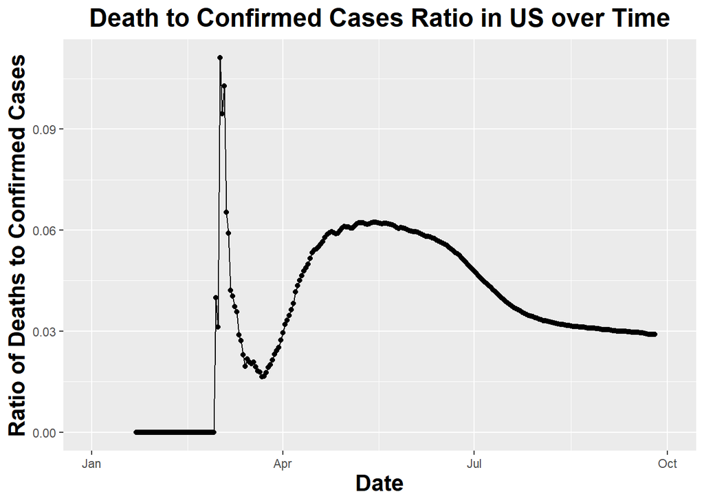

```r
# Plot -
plot_time_series_US_ratio <- ggplot(time_series_US_ratio, aes(x = Date, y = Death_Confirmed_Ratio)) +
  geom_point() +
  geom_line() +
  scale_x_date(limits = as.Date(c('2020-01-01', '2020-10-01'))) + # Make is so the Jan label is on the x axis
  labs(y = "Ratio of Deaths to Confirmed Cases", title = "Death to Confirmed Cases Ratio in US over Time") +
  theme(axis.title = element_text(size = 16, face = 'bold'),
        plot.title = element_text (size = 18, face = 'bold', hjust = 0.5))
plot_time_series_US_ratio
```

```r
# Note the massive spike in March due to the large ratio of deaths to confirmed cases
# that happened at the beginning of the pandemic in the US.It's pretty jarring
```

## Exercise 7

Make a single graph of deaths over time for the 10 countries with the highest total deaths

```r
# First, determine which countries have the highest deaths as of latest date in time series
# Unfortunately, I can't think of a more eloquent way to do so right now
deaths_top10 <- time_series_deaths %>%
  select(-c(Lat, Long)) %>% # Remove the extraneous variables
  # First, need to sum total deaths for all countries since some have state data
  group_by(Country_Region) %>%
  summarize(Total_Latest_Deaths = sum(`9/25/20`)) %>% # Not sure how to specify the data in the last column in R
  arrange(desc(Total_Latest_Deaths)) %>%
  slice(0:10)
deaths_top10 # Check to see the top 10 countries
```

```
## # A tibble: 10 x 2
##    Country_Region Total_Latest_Deaths
##    <chr>                        <dbl>
##  1 US                          203750
##  2 Brazil                      140537
##  3 India                        92290
##  4 Mexico                       75844
##  5 United Kingdom               42025
##  6 Italy                        35801
##  7 Peru                         32037
##  8 France                       31675
##  9 Spain                        31232
## 10 Iran                         25222
```

```r
time_series_deaths_top10 <- time_series_deaths %>%
  select(-c(Lat, Long)) %>% # Remove the extraneous variables
  filter(Country_Region %in% deaths_top10$Country_Region) %>%  # Filter for just the top 10 countries by deaths
  # Need to combine data for regions that have state data (i.e., France)
  # Only way I know how to right now is by pivoting and summarizing. I don't know how
  # to do loops in R right now
  pivot_longer(-c(Province_State, Country_Region), names_to = "Date", values_to = "Deaths") %>%
  group_by(Country_Region, Date) %>%
  summarize(Total_Deaths = sum(Deaths))
mdy(time_series_deaths_top10$Date) -> time_series_deaths_top10$Date

head(time_series_deaths_top10)
```

```
## # A tibble: 6 x 3
## # Groups:   Country_Region [1]
##   Country_Region Date       Total_Deaths
##   <chr>          <date>            <dbl>
## 1 Brazil         2020-01-22            0
## 2 Brazil         2020-01-23            0
## 3 Brazil         2020-01-24            0
## 4 Brazil         2020-01-25            0
## 5 Brazil         2020-01-26            0
## 6 Brazil         2020-01-27            0
```

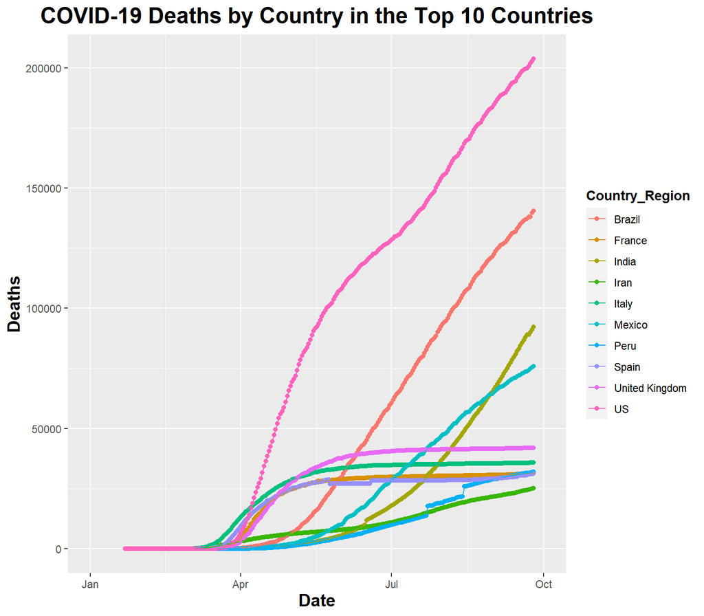

```r
# Data are now ready to plot in one large graph
plot_top10_deaths_worldwide <- ggplot(time_series_deaths_top10, aes(x = Date, y = Total_Deaths, color = Country_Region)) +
  geom_point() +
  geom_line() +
  labs(y = "Deaths", title = "COVID-19 Deaths by Country in the Top 10 Countries") +
  scale_x_date(limits = as.Date(c('2020-01-01', '2020-10-01'))) +
  theme(plot.title = element_text(size = 18, face = "bold", hjust = 0.5),
        axis.title = element_text(size = 14, face = "bold"),
        legend.title = element_text(face = 'bold'))
plot_top10_deaths_worldwide
```

## Exercise 8

Use facet_wrap() to graph the data above in their own little graphs, adjusting the settings to make the graph look better

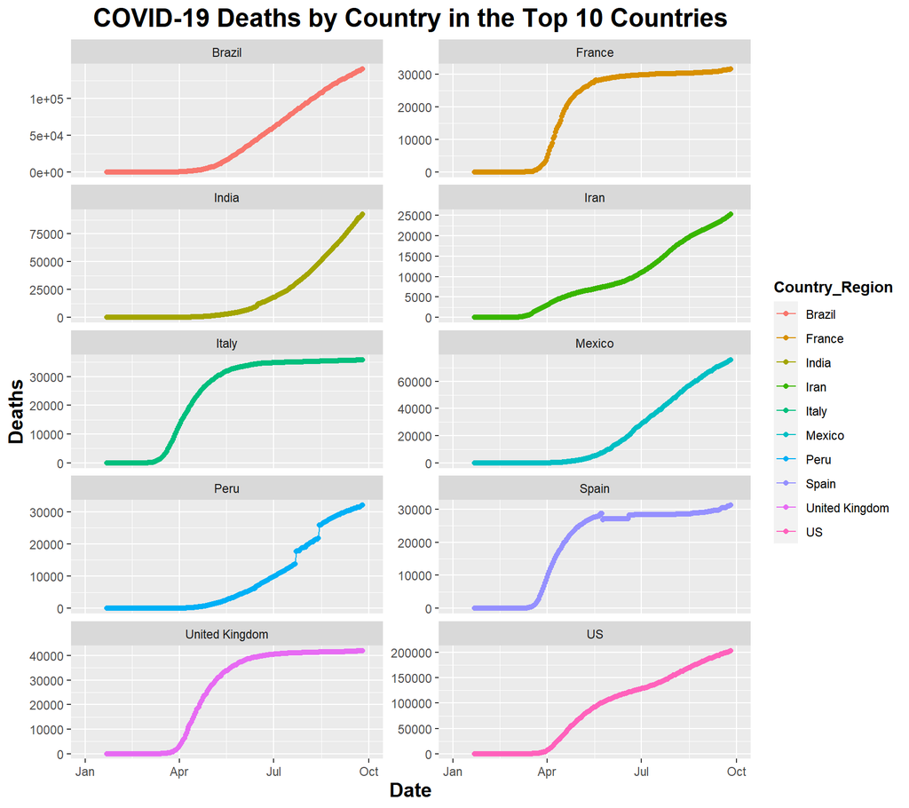

```r
plot_top10_deaths_worldwide_facet <- ggplot(time_series_deaths_top10, aes(x = Date, y = Total_Deaths, color = Country_Region)) +
  geom_point() +
  geom_line() +
  facet_wrap(~Country_Region, nrow = 5, scales = "free_y") + # Made the y axes scale independently to see trends
  labs(y = "Deaths", title = "COVID-19 Deaths by Country in the Top 10 Countries") +
  scale_x_date(limits = as.Date(c('2020-01-01', '2020-10-01'))) +
  theme(plot.title = element_text(size = 18, face = "bold", hjust = 0.5),
        axis.title = element_text(size = 14, face = "bold"),
        legend.title = element_text(face = 'bold'))
plot_top10_deaths_worldwide_facet
```

## Exercise 9

Use facet_wrap() to graph the time series data for the confirmed cases in all US states and territories over time. Format the graphs to look nice again.

```r
# Download the data from the Github site and read to memory
download.file(url = 'https://raw.githubusercontent.com/CSSEGISandData/COVID-19/master/csse_covid_19_data/csse_covid_19_time_series/time_series_covid19_confirmed_US.csv',
              destfile = 'data/time_series_covid19_confirmed_US.csv')
```

```r
time_series_confirmed_US <- read_csv('data/time_series_covid19_confirmed_US.csv') %>%
# Very large document with similar organization as before. States are in Province_State,
# plus some extra variables (columns) before. Still has Country_Region, Lat, and Long
# variables, too. Filter out these extra columns (all but Province_State, Combined_Key,
# and the dates) by using select().
  select(-c(UID, iso2, iso3, code3, FIPS, Admin2, Lat, Long_, Country_Region))  %>%
  pivot_longer(-c(Province_State, Combined_Key), names_to = "Date", values_to = "Confirmed") %>%
  group_by(Province_State, Date) %>%
  summarize(Total_Confirmed = sum(Confirmed))
head(time_series_confirmed_US) # Check that the data set was parsed properly
```

```
## # A tibble: 6 x 3
## # Groups:   Province_State [1]
##   Province_State Date    Total_Confirmed
##   <chr>          <chr>             <dbl>
## 1 Alabama        1/22/20               0
## 2 Alabama        1/23/20               0
## 3 Alabama        1/24/20               0
## 4 Alabama        1/25/20               0
## 5 Alabama        1/26/20               0
## 6 Alabama        1/27/20               0
```

```r
length(unique(time_series_confirmed_US$Province_State)) # 58 unique entries
```

```
## [1] 58
```

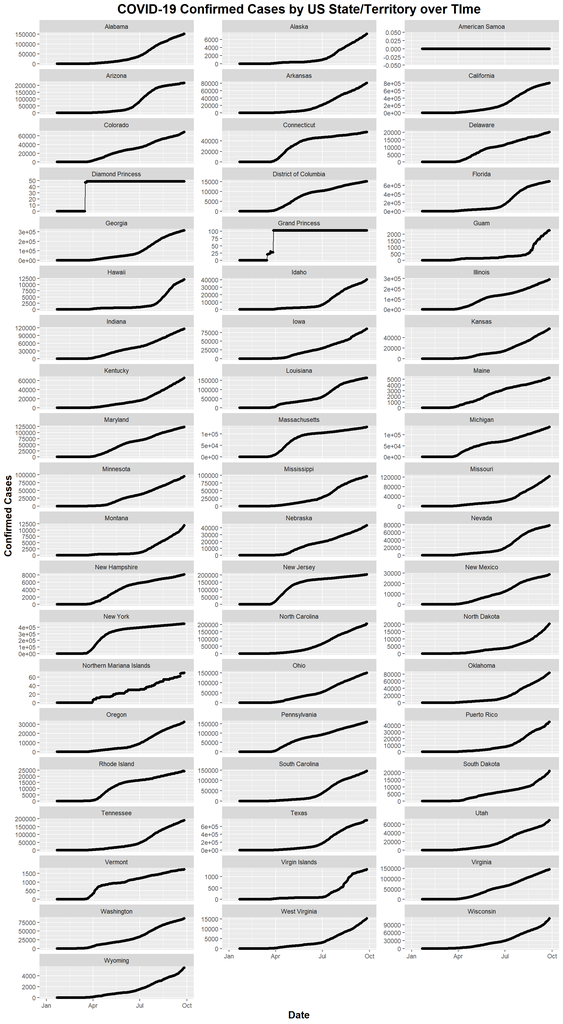

```r
mdy(time_series_confirmed_US$Date) -> time_series_confirmed_US$Date # Don't forget this!

# Now plot the data
plot_time_series_confirmed_States <- ggplot(time_series_confirmed_US, aes(x = Date, y = Total_Confirmed, group = Province_State)) + # Must gropu by state to graph properly
  geom_point() +
  geom_line() +
  facet_wrap(~Province_State, ncol = 3, scales = 'free_y') +
  labs(y = "Confirmed Cases", title = "COVID-19 Confirmed Cases by US State/Territory over TIme") +
  scale_x_date(limits = as.Date(c('2020-01-01', '2020-10-01'))) +
  theme(plot.title = element_text(size = 18, face = "bold", hjust = 0.5),
        axis.title = element_text(size = 14, face = "bold"),
        legend.title = element_text(face = 'bold'))
plot_time_series_confirmed_States
```

## Exercise 10

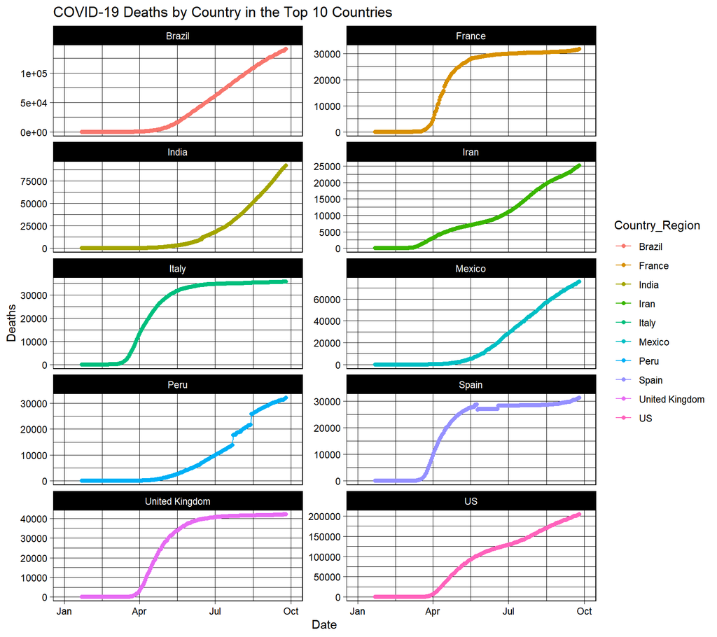

```r
plot_top10_deaths_worldwide_facet_theme <- plot_top10_deaths_worldwide_facet +
  theme_linedraw()
plot_top10_deaths_worldwide_facet_theme
```